# Lab-6-part-1

Isabel Sassoon

2022-10-20

# Multiple Regression Lab

This covers *multiple regression* and focuses on approaches to model selection.

We are using a data set (seen in the lecture) on air pollution studies.

### Loading the required libraries

```r
library(ggplot2)
#library(ggpubr)
library(mgcv)
library(tree)
```

Multiple regression can help us answer the following question:

**How is ozone concentration related to wind speed, air temperature, and the intensity of solar radiation?**

The dependent variable is ozone concentration. In this case we have a *numerical dependent variable and all the explanatory variables are also numeric*.

Lets read in the data….

```r
ozone.pollution<-read.csv("lab-6-part-1-data/ozone.data.csv")
```

This data set has 111 rows and 4 columns.

```r
names(ozone.pollution)
```

```
## [1] "rad"   "temp"  "wind"  "ozone"
```

Lets explore the data numerically using the summary function first:

```r
summary(ozone.pollution)
```

```
##       rad             temp            wind            ozone
##  Min.   :  7.0   Min.   :57.00   Min.   : 2.300   Min.   :  1.0
##  1st Qu.:113.5   1st Qu.:71.00   1st Qu.: 7.400   1st Qu.: 18.0
##  Median :207.0   Median :79.00   Median : 9.700   Median : 31.0
##  Mean   :184.8   Mean   :77.79   Mean   : 9.939   Mean   : 42.1
##  3rd Qu.:255.5   3rd Qu.:84.50   3rd Qu.:11.500   3rd Qu.: 62.0
##  Max.   :334.0   Max.   :97.00   Max.   :20.700   Max.   :168.0
```

There are no missing values, extreme values, or strange patterns in the summaries.

We can then explore the data graphically. Plots can be done one by one but this *pairs* plot function will do this all in one go. It is useful when all your columns are numeric.

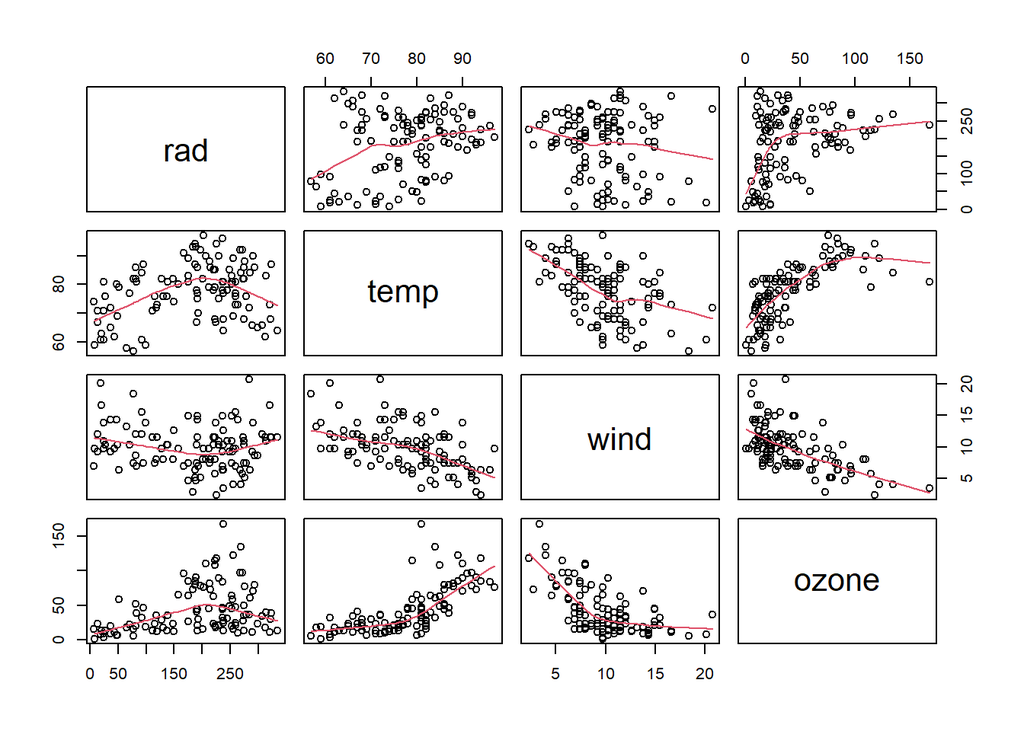

```r
pairs(ozone.pollution, panel = panel.smooth)
```

The response variable, ozone concentration is shown on the y-axis of the bottom row of these panels. There appears to be a strong negative relationship with wind speed, a positive correlation with temperature and an unclear relationship with radiation.

## OPTIONAL

One way to start a multiple regression problem is using a non-parametric smoother in a GAM.

```r
ozone.gam<-gam(ozone.pollution$ozone~s(ozone.pollution$rad)+s(ozone.pollution$temp)+s(ozone.pollution$wind))
summary(ozone.gam)
```

```
##
## Family: gaussian
## Link function: identity
##
## Formula:
## ozone.pollution$ozone ~ s(ozone.pollution$rad) + s(ozone.pollution$temp) +
##     s(ozone.pollution$wind)
##
## Parametric coefficients:
##             Estimate Std. Error t value Pr(>|t|)
## (Intercept)    42.10       1.66   25.36   <2e-16 ***
## ---
## Signif. codes:  0 '***' 0.001 '**' 0.01 '*' 0.05 '.' 0.1 ' ' 1
##
## Approximate significance of smooth terms:
##                           edf Ref.df      F p-value
## s(ozone.pollution$rad)  2.763  3.451  3.964 0.00859 **
## s(ozone.pollution$temp) 3.841  4.762 11.612 < 2e-16 ***
## s(ozone.pollution$wind) 2.918  3.666 13.770 < 2e-16 ***
## ---
## Signif. codes:  0 '***' 0.001 '**' 0.01 '*' 0.05 '.' 0.1 ' ' 1
##
## R-sq.(adj) =  0.724   Deviance explained = 74.8%
## GCV =    338  Scale est. = 305.96    n = 111
```

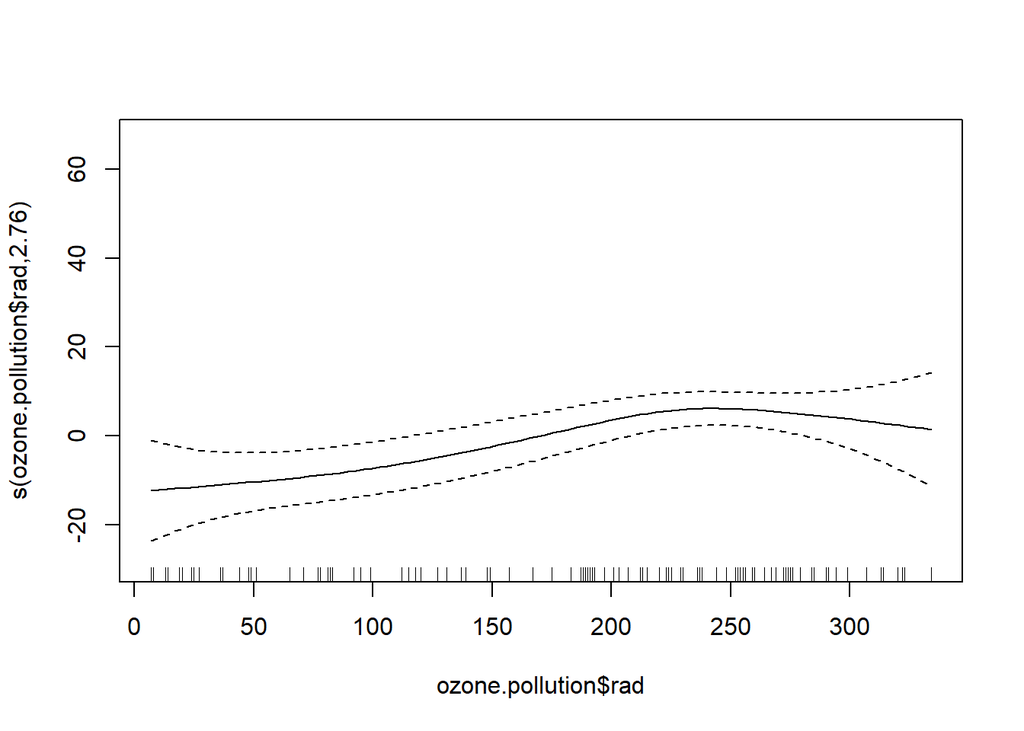

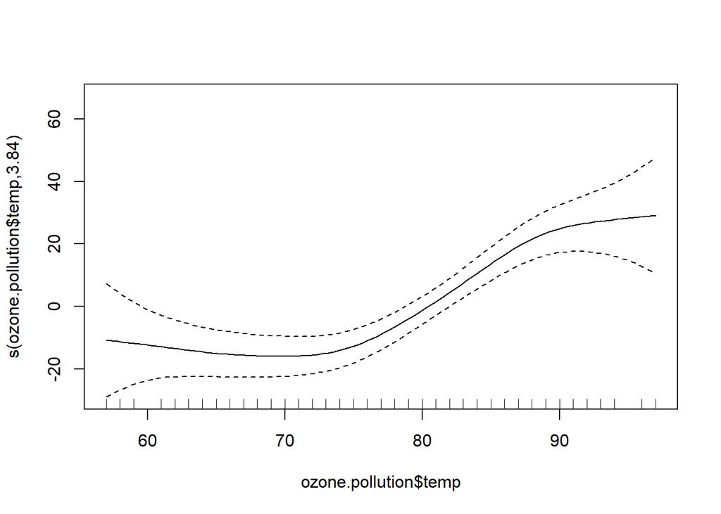

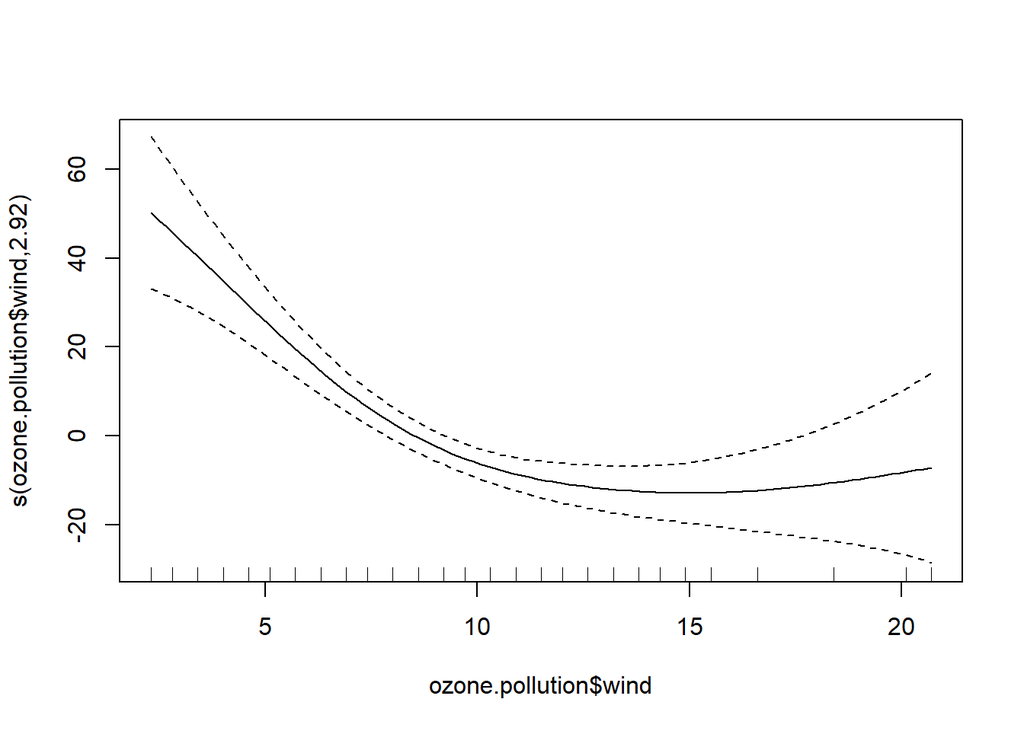

```r
plot(ozone.gam)
```

This is useful as it can highlight some evident curvature in the relationships between the target and explanatory variables.

Another optional approach to see if there are interactions, is using a regression tree.

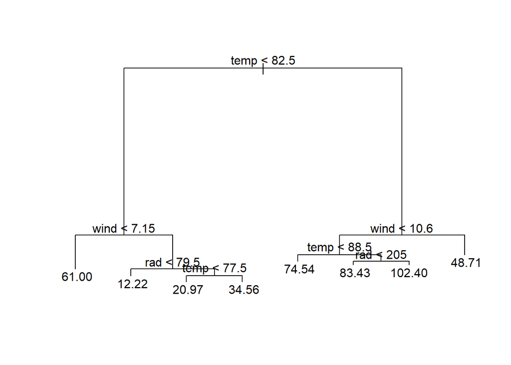

```r
ozone.tree<-tree(ozone.pollution$ozone~., data = ozone.pollution)
plot(ozone.tree)
text(ozone.tree)
```

This can tell us about the structure of the data, and the top factors affecting the value of our dependent variable.

END OF OPTIONAL SECTION ***

From the plots of the data (and confirmed by the GAM and Tree - if using) there is reason to assume that some polynomial relation is possible. Therefore our **most complicated model** will include some quadratic terms and interactions.

*NOTE - this is being done manually step by step. Using step() starting from the Maximal model or the model that is informed by exploring the data and the context is perfectly acceptable*

### Model 1

This is our maximal model and it also includes quadratic terms and interactions.

```r
m1.lm<-lm(ozone~temp*wind*rad+I(temp^2)+ I(wind^2)+ I(rad^2), data=ozone.pollution )
summary(m1.lm)
```

```
##
## Call:
## lm(formula = ozone ~ temp * wind * rad + I(temp^2) + I(wind^2) +
##     I(rad^2), data = ozone.pollution)
##
## Residuals:
##     Min      1Q  Median      3Q     Max
## -38.894 -11.205  -2.736   8.809  70.551
##
## Coefficients:
##                 Estimate Std. Error t value Pr(>|t|)
## (Intercept)    5.683e+02  2.073e+02   2.741  0.00725 **
## temp          -1.076e+01  4.303e+00  -2.501  0.01401 *
## wind          -3.237e+01  1.173e+01  -2.760  0.00687 **
## rad           -3.117e-01  5.585e-01  -0.558  0.57799
## I(temp^2)      5.833e-02  2.396e-02   2.435  0.01668 *
## I(wind^2)      6.106e-01  1.469e-01   4.157 6.81e-05 ***
## I(rad^2)      -3.619e-04  2.573e-04  -1.407  0.16265
## temp:wind      2.377e-01  1.367e-01   1.739  0.08519 .
## temp:rad       8.403e-03  7.512e-03   1.119  0.26602
## wind:rad       2.054e-02  4.892e-02   0.420  0.67552
## temp:wind:rad -4.324e-04  6.595e-04  -0.656  0.51358
## ---
## Signif. codes:  0 '***' 0.001 '**' 0.01 '*' 0.05 '.' 0.1 ' ' 1
##
## Residual standard error: 17.82 on 100 degrees of freedom
## Multiple R-squared:  0.7394, Adjusted R-squared:  0.7133
## F-statistic: 28.37 on 10 and 100 DF,  p-value: < 2.2e-16
```

This model has a significant F score, a great $r^2$ and some coefficients (but not all) are significant.

The three way interaction is clearly not significant so we can start to simplify by removing it.

### Model 2

```r
m2.lm<-lm(ozone~temp*wind*rad+I(temp^2)+ I(wind^2)+ I(rad^2)-temp:wind:rad, data=ozone.pollution)
summary(m2.lm)
```

```
##
## Call:
## lm(formula = ozone ~ temp * wind * rad + I(temp^2) + I(wind^2) +
##     I(rad^2) - temp:wind:rad, data = ozone.pollution)
##
## Residuals:
##     Min      1Q  Median      3Q     Max
## -39.611 -11.455  -2.901   8.548  70.325
##
## Coefficients:
##               Estimate Std. Error t value Pr(>|t|)
## (Intercept)  5.245e+02  1.957e+02   2.680   0.0086 **
## temp        -1.021e+01  4.209e+00  -2.427   0.0170 *
## wind        -2.802e+01  9.645e+00  -2.906   0.0045 **
## rad          2.628e-02  2.142e-01   0.123   0.9026
## I(temp^2)    5.953e-02  2.382e-02   2.499   0.0141 *
## I(wind^2)    6.173e-01  1.461e-01   4.225 5.25e-05 ***
## I(rad^2)    -3.388e-04  2.541e-04  -1.333   0.1855
## temp:wind    1.734e-01  9.497e-02   1.825   0.0709 .
## temp:rad     3.750e-03  2.459e-03   1.525   0.1303
## wind:rad    -1.127e-02  6.277e-03  -1.795   0.0756 .
## ---
## Signif. codes:  0 '***' 0.001 '**' 0.01 '*' 0.05 '.' 0.1 ' ' 1
##
## Residual standard error: 17.77 on 101 degrees of freedom
## Multiple R-squared:  0.7383, Adjusted R-squared:  0.715
## F-statistic: 31.66 on 9 and 101 DF,  p-value: < 2.2e-16
```

### Model 3

```r
m3.lm<-update(m2.lm,~.-wind:rad)
summary(m3.lm)
```

```
##
## Call:
## lm(formula = ozone ~ temp + wind + rad + I(temp^2) + I(wind^2) +
##     I(rad^2) + temp:wind + temp:rad, data = ozone.pollution)
##
## Residuals:
##     Min      1Q  Median      3Q     Max
## -43.174 -11.020  -4.077   7.316  74.787
##
## Coefficients:
##               Estimate Std. Error t value Pr(>|t|)
## (Intercept)  4.832e+02  1.964e+02   2.460 0.015592 *
## temp        -9.069e+00  4.205e+00  -2.157 0.033391 *
## wind        -2.472e+01  9.570e+00  -2.583 0.011223 *
## rad         -1.812e-01  1.823e-01  -0.994 0.322483
## I(temp^2)    5.461e-02  2.392e-02   2.283 0.024507 *
## I(wind^2)    5.809e-01  1.463e-01   3.972 0.000133 ***
## I(rad^2)    -3.438e-04  2.569e-04  -1.338 0.183762
## temp:wind    1.137e-01  8.993e-02   1.264 0.208995
## temp:rad     4.925e-03  2.396e-03   2.055 0.042402 *
## ---
## Signif. codes:  0 '***' 0.001 '**' 0.01 '*' 0.05 '.' 0.1 ' ' 1
##
## Residual standard error: 17.96 on 102 degrees of freedom
## Multiple R-squared:  0.7299, Adjusted R-squared:  0.7087
## F-statistic: 34.46 on 8 and 102 DF,  p-value: < 2.2e-16
```

And now we remove the wind and temperature interaction

### Model 4

```r
m4.lm<-update(m3.lm, ~.-temp:wind)
summary(m4.lm)
```

```
##
## Call:
## lm(formula = ozone ~ temp + wind + rad + I(temp^2) + I(wind^2) +
##     I(rad^2) + temp:rad, data = ozone.pollution)
##
## Residuals:
##     Min      1Q  Median      3Q     Max
## -44.258 -11.174  -3.325   9.562  78.416
##
## Coefficients:
##               Estimate Std. Error t value Pr(>|t|)
## (Intercept)  2.699e+02  1.010e+02   2.673  0.00874 **
## temp        -5.090e+00  2.797e+00  -1.820  0.07173 .
## wind        -1.296e+01  2.276e+00  -5.695 1.17e-07 ***
## rad         -1.902e-01  1.827e-01  -1.041  0.30013
## I(temp^2)    3.650e-02  1.921e-02   1.900  0.06027 .
## I(wind^2)    4.454e-01  9.979e-02   4.463 2.07e-05 ***
## I(rad^2)    -2.994e-04  2.552e-04  -1.173  0.24348
## temp:rad     4.857e-03  2.403e-03   2.022  0.04578 *
## ---
## Signif. codes:  0 '***' 0.001 '**' 0.01 '*' 0.05 '.' 0.1 ' ' 1
##
## Residual standard error: 18.01 on 103 degrees of freedom
## Multiple R-squared:  0.7257, Adjusted R-squared:  0.707
## F-statistic: 38.93 on 7 and 103 DF,  p-value: < 2.2e-16
```

We can use the **update* function to stop too much typing!

### Model 5

```r
m5.lm<-update(m4.lm, ~.-I(rad^2))
summary(m5.lm)
```

```
##
## Call:
## lm(formula = ozone ~ temp + wind + rad + I(temp^2) + I(wind^2) +
##     temp:rad, data = ozone.pollution)
##
## Residuals:
##     Min      1Q  Median      3Q     Max
## -43.764 -11.157  -3.327   8.499  78.851
##
## Coefficients:
##               Estimate Std. Error t value Pr(>|t|)
## (Intercept) 262.651900 100.961024   2.602   0.0106 *
## temp         -4.902890   2.797877  -1.752   0.0827 .
## wind        -13.048559   2.278668  -5.726 1.00e-07 ***
## rad          -0.253116   0.174922  -1.447   0.1509
## I(temp^2)     0.036480   0.019248   1.895   0.0608 .
## I(wind^2)     0.446673   0.099963   4.468 2.01e-05 ***
## temp:rad      0.004343   0.002366   1.835   0.0693 .
## ---
## Signif. codes:  0 '***' 0.001 '**' 0.01 '*' 0.05 '.' 0.1 ' ' 1
##
## Residual standard error: 18.04 on 104 degrees of freedom
## Multiple R-squared:  0.722,  Adjusted R-squared:  0.706
## F-statistic: 45.02 on 6 and 104 DF,  p-value: < 2.2e-16
```

Now we find that temp:rad is not significant so we will remove it from the next model

### Model 6

```r
m6.lm<-update(m5.lm, ~.-temp:rad)
summary(m6.lm)
```

```
##
## Call:
## lm(formula = ozone ~ temp + wind + rad + I(temp^2) + I(wind^2),
##     data = ozone.pollution)
##
## Residuals:
##     Min      1Q  Median      3Q     Max
## -48.044 -10.796  -4.138   8.131  80.098
##
## Coefficients:
##              Estimate Std. Error t value Pr(>|t|)
## (Intercept) 291.16758  100.87723   2.886  0.00473 **
## temp         -6.33955    2.71627  -2.334  0.02150 *
## wind        -13.39674    2.29623  -5.834 6.05e-08 ***
## rad           0.06586    0.02005   3.285  0.00139 **
## I(temp^2)     0.05102    0.01774   2.876  0.00488 **
## I(wind^2)     0.46464    0.10060   4.619 1.10e-05 ***
## ---
## Signif. codes:  0 '***' 0.001 '**' 0.01 '*' 0.05 '.' 0.1 ' ' 1
##
## Residual standard error: 18.25 on 105 degrees of freedom
## Multiple R-squared:  0.713,  Adjusted R-squared:  0.6994
## F-statistic: 52.18 on 5 and 105 DF,  p-value: < 2.2e-16
```

This is looking promising, as all the coefficients are significant we don’t need to remove any. But we should check the residuals

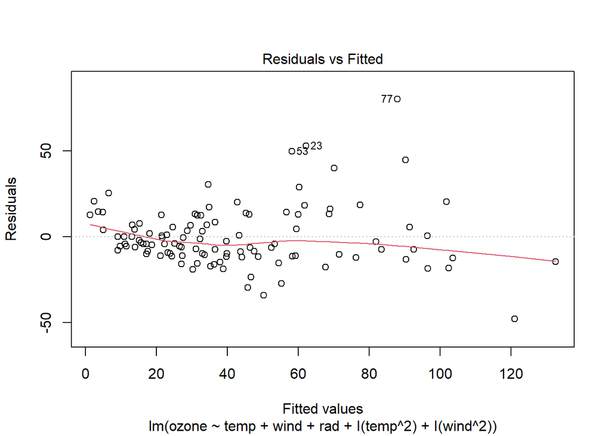

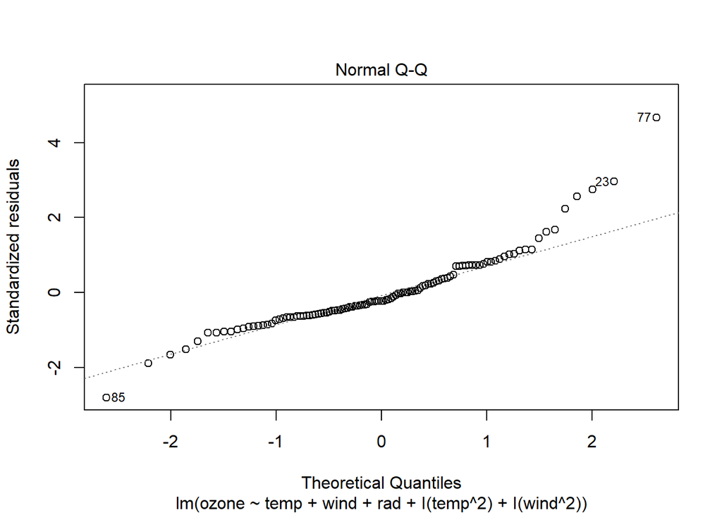

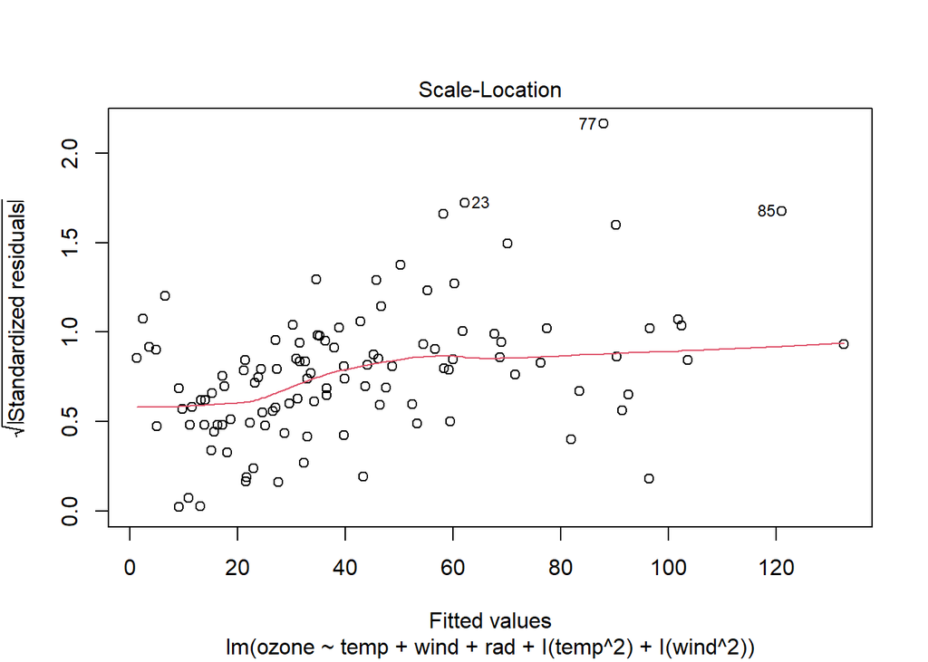

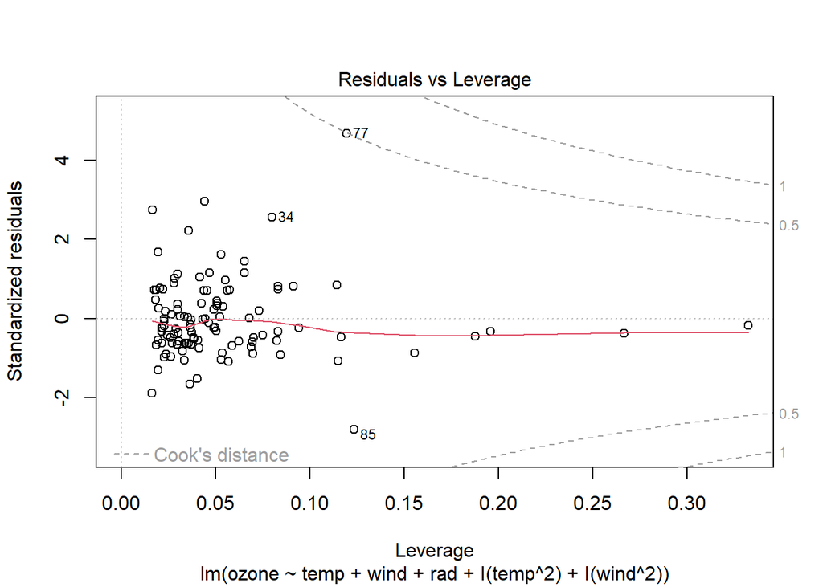

```r
plot(m6.lm)
```

We can see in the first plot that the spread of the residuals is greater for higher values on the x-axis. This is called heteroscedasticity. There is also a S shape emerging in the qq-plot.

In order to adjust for this a transformation of the dependent variable can help. In this case a log transformation. This is ok to use as long as there are no zeros in the dependent variable.

Now once the dependent variable is transformed, the whole structure and linearity of the relationships changes. We will start from the beginning, but we can use the step function as a shortcut.

So firstly we go back to the full model or most complicated model (model 1), but with the transformed dependent variable:

### Model 7

```r
#log transform
m7.lm<-lm(log(ozone)~temp*wind*rad+I(temp^2)+ I(wind^2)+ I(rad^2),data=ozone.pollution)
summary(m7.lm)
```

```
##
## Call:
## lm(formula = log(ozone) ~ temp * wind * rad + I(temp^2) + I(wind^2) +
##     I(rad^2), data = ozone.pollution)
##
## Residuals:
##      Min       1Q   Median       3Q      Max
## -1.91943 -0.24169 -0.01742  0.28213  1.11802
##
## Coefficients:
##                 Estimate Std. Error t value Pr(>|t|)
## (Intercept)    2.803e+00  5.676e+00   0.494   0.6225
## temp          -3.018e-02  1.178e-01  -0.256   0.7983
## wind          -9.812e-02  3.211e-01  -0.306   0.7605
## rad            2.771e-02  1.529e-02   1.812   0.0729 .
## I(temp^2)      6.034e-04  6.559e-04   0.920   0.3598
## I(wind^2)      8.732e-03  4.021e-03   2.172   0.0322 *
## I(rad^2)      -1.489e-05  7.043e-06  -2.114   0.0370 *
## temp:wind     -1.985e-03  3.742e-03  -0.530   0.5971
## temp:rad      -2.507e-04  2.056e-04  -1.219   0.2256
## wind:rad      -2.001e-03  1.339e-03  -1.494   0.1382
## temp:wind:rad  2.535e-05  1.805e-05   1.404   0.1634
## ---
## Signif. codes:  0 '***' 0.001 '**' 0.01 '*' 0.05 '.' 0.1 ' ' 1
##
## Residual standard error: 0.4877 on 100 degrees of freedom
## Multiple R-squared:  0.7116, Adjusted R-squared:  0.6827
## F-statistic: 24.67 on 10 and 100 DF,  p-value: < 2.2e-16
```

Then use the step function to get to our *minimal adequate model*, we do this instead of going step by step manually as we did before.

```r
m8.lm<-step(m7.lm)
```

```
## Start:  AIC=-148.98
## log(ozone) ~ temp * wind * rad + I(temp^2) + I(wind^2) + I(rad^2)
##
##                 Df Sum of Sq    RSS     AIC
## - I(temp^2)      1   0.20130 23.988 -150.05
## <none>                       23.787 -148.98
## - temp:wind:rad  1   0.46883 24.256 -148.82
## - I(rad^2)       1   1.06316 24.850 -146.13
## - I(wind^2)      1   1.12186 24.909 -145.87
##
## Step:  AIC=-150.05
## log(ozone) ~ temp + wind + rad + I(wind^2) + I(rad^2) + temp:wind +
##     temp:rad + wind:rad + temp:wind:rad
##
##                 Df Sum of Sq    RSS     AIC
## - temp:wind:rad  1   0.42563 24.414 -150.10
## <none>                       23.988 -150.05
## - I(wind^2)      1   0.92801 24.916 -147.84
## - I(rad^2)       1   1.00480 24.993 -147.49
##
## Step:  AIC=-150.1
## log(ozone) ~ temp + wind + rad + I(wind^2) + I(rad^2) + temp:wind +
##     temp:rad + wind:rad
##
##             Df Sum of Sq    RSS     AIC
## - temp:wind  1   0.01438 24.428 -152.03
## - temp:rad   1   0.09359 24.508 -151.67
## - wind:rad   1   0.11815 24.532 -151.56
## <none>                   24.414 -150.10
## - I(wind^2)  1   0.87300 25.287 -148.20
## - I(rad^2)   1   1.22558 25.639 -146.66
##
## Step:  AIC=-152.03
## log(ozone) ~ temp + wind + rad + I(wind^2) + I(rad^2) + temp:rad +
##     wind:rad
##
##             Df Sum of Sq    RSS     AIC
## - temp:rad   1   0.08429 24.512 -153.65
## - wind:rad   1   0.10377 24.532 -153.56
## <none>                   24.428 -152.03
```

[output cut: 8 more lines]

```
## <none>                   24.513 -153.65
## - I(rad^2)   1    1.1311 25.644 -150.64
## - I(wind^2)  1    1.5001 26.013 -149.06
## - temp       1   10.7274 35.240 -115.36
##
## Step:  AIC=-154.77
## log(ozone) ~ temp + wind + rad + I(wind^2) + I(rad^2)
##
##             Df Sum of Sq    RSS     AIC
## <none>                   24.707 -154.77
## - I(rad^2)   1    1.1216 25.828 -151.84
## - I(wind^2)  1    1.9234 26.630 -148.45
## - rad        1    2.4314 27.138 -146.35
## - wind       1    3.3350 28.042 -142.72
## - temp       1   10.6366 35.343 -117.03
```

```r
summary(m8.lm)
```

```
##
## Call:
## lm(formula = log(ozone) ~ temp + wind + rad + I(wind^2) + I(rad^2),
##     data = ozone.pollution)
##
## Residuals:
##      Min       1Q   Median       3Q      Max
## -1.85551 -0.25578  0.00248  0.31349  1.16251
##
## Coefficients:
##               Estimate Std. Error t value Pr(>|t|)
## (Intercept)  7.724e-01  6.350e-01   1.216 0.226543
## temp         4.193e-02  6.237e-03   6.723 9.52e-10 ***
## wind        -2.211e-01  5.874e-02  -3.765 0.000275 ***
## rad          7.466e-03  2.323e-03   3.215 0.001736 **
## I(wind^2)    7.390e-03  2.585e-03   2.859 0.005126 **
## I(rad^2)    -1.470e-05  6.734e-06  -2.183 0.031246 *
## ---
## Signif. codes:  0 '***' 0.001 '**' 0.01 '*' 0.05 '.' 0.1 ' ' 1
##
## Residual standard error: 0.4851 on 105 degrees of freedom
## Multiple R-squared:  0.7004, Adjusted R-squared:  0.6861
## F-statistic:  49.1 on 5 and 105 DF,  p-value: < 2.2e-16
```

The step function creates a long output so what we are looking for is the last part, which proposes the *minimal adequate model* where the step wise process stops.

and check its residuals are obtained using:

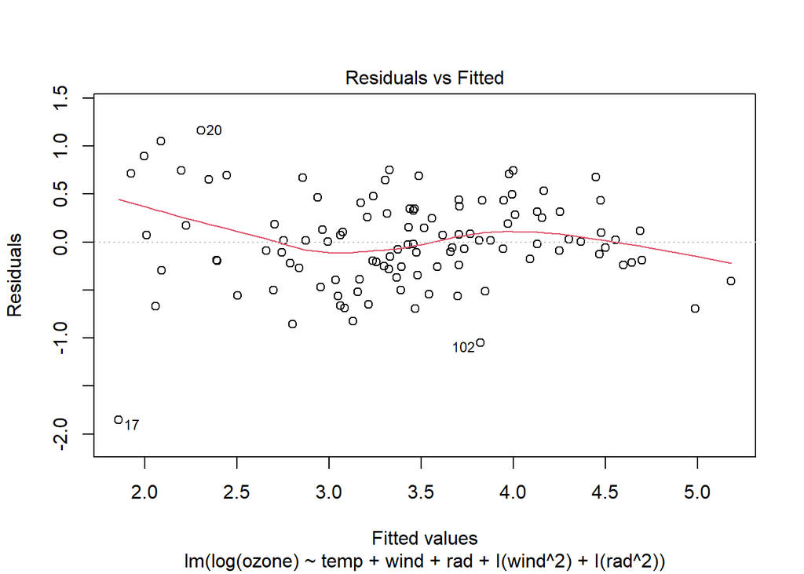

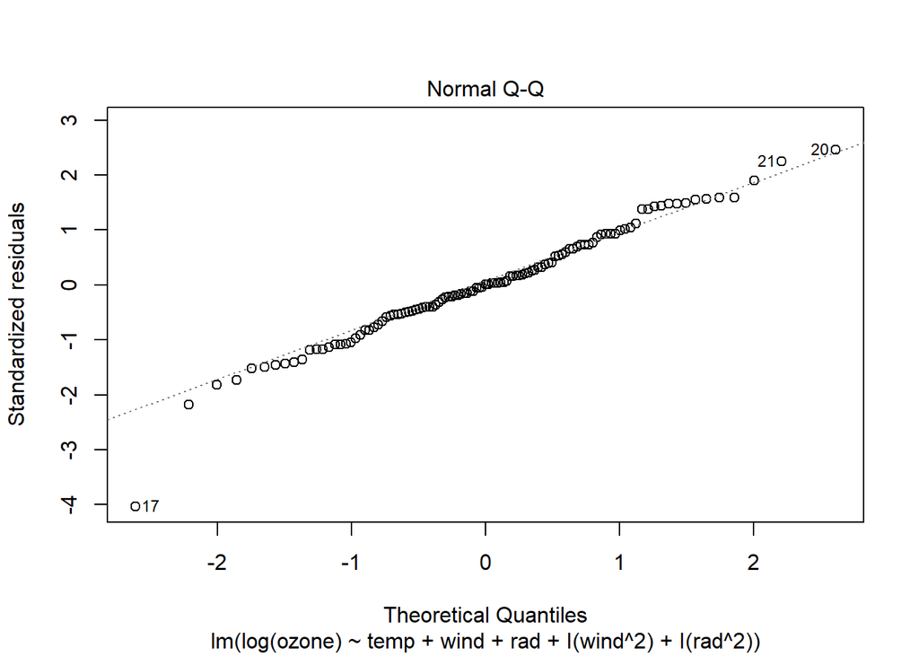

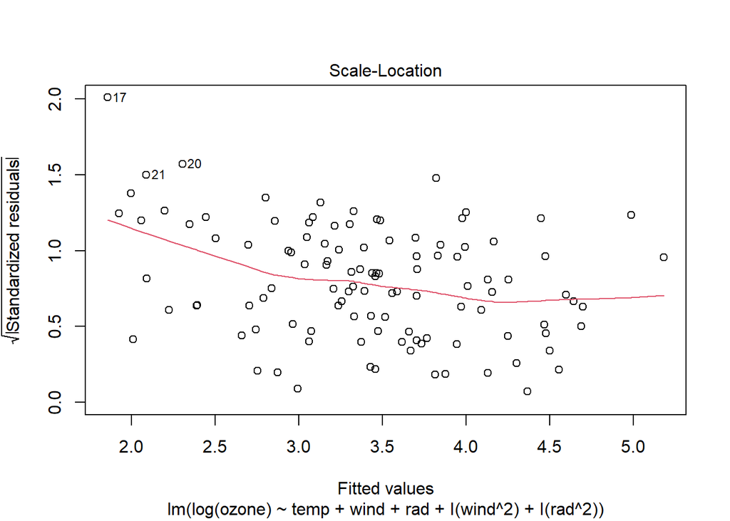

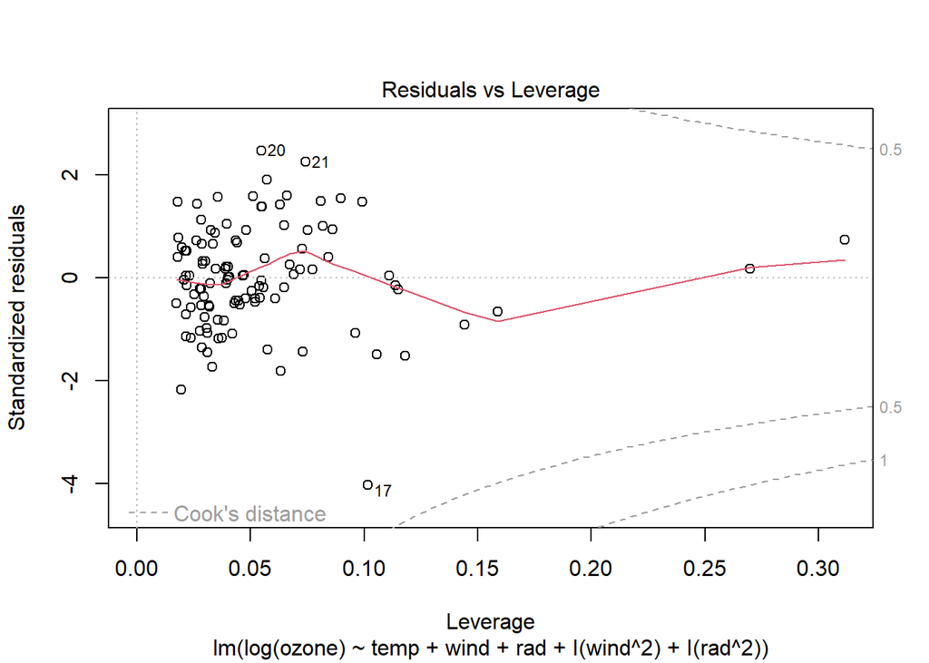

```r
plot(m8.lm)
```

All of the four residual diagnostic plots are looking better!

We can learn that if the temperature increases then so does the log(ozone), both wind and radiation have a mixed effect on the log(ozone) - this is reflected in positive coefficients and negative coefficients for the variable and the variable squared respectively (in the case of rad).